# Week 3 Lab Some Solutions

# 1 Question 1

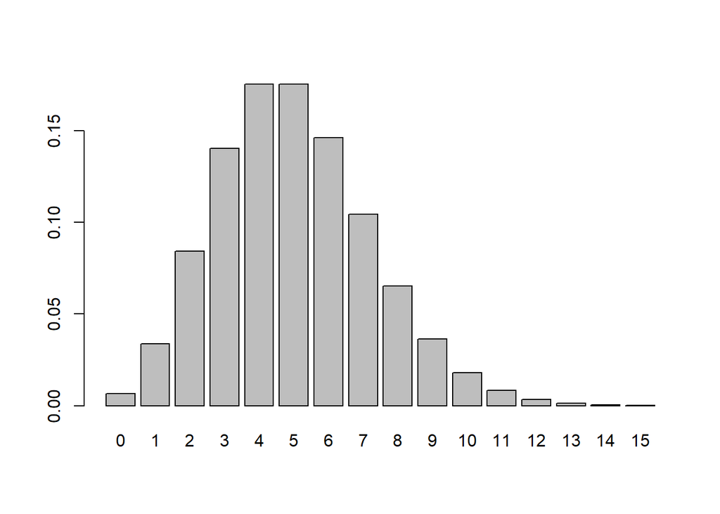

```r
barplot(dpois(0:15, 5), names=0:15)
```

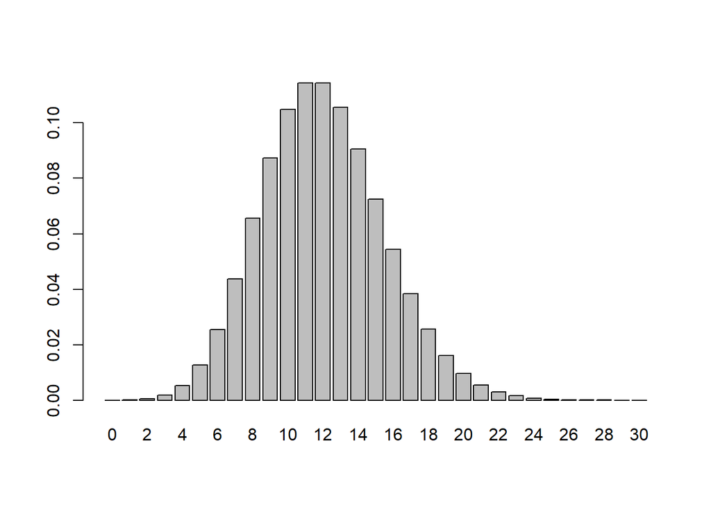

```r
barplot(dpois(0:30, 12), names=0:30)
```

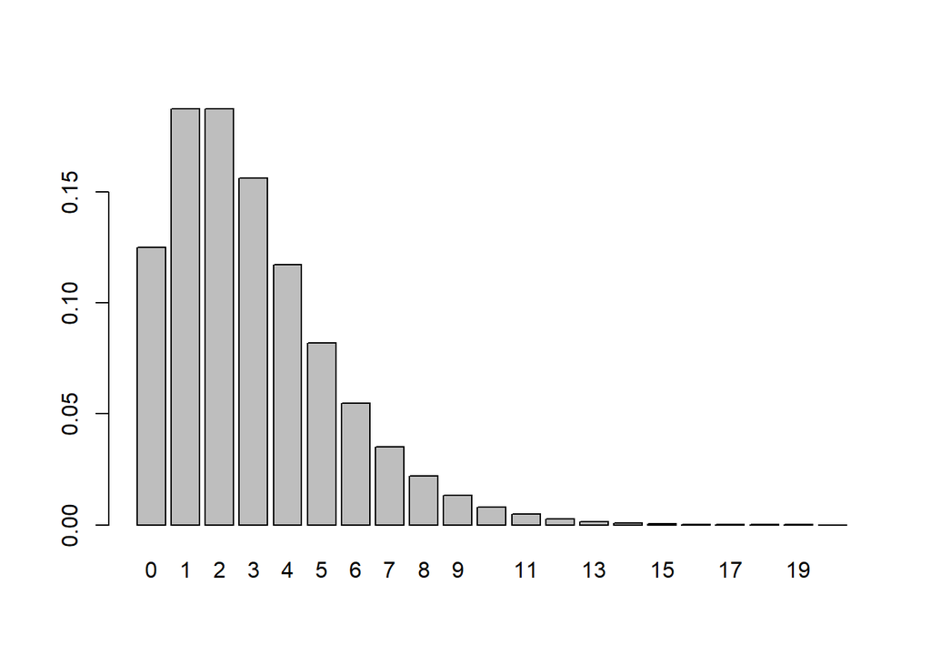

```r
barplot(dnbinom(0:20, 3, 0.5), names=0:20)
```

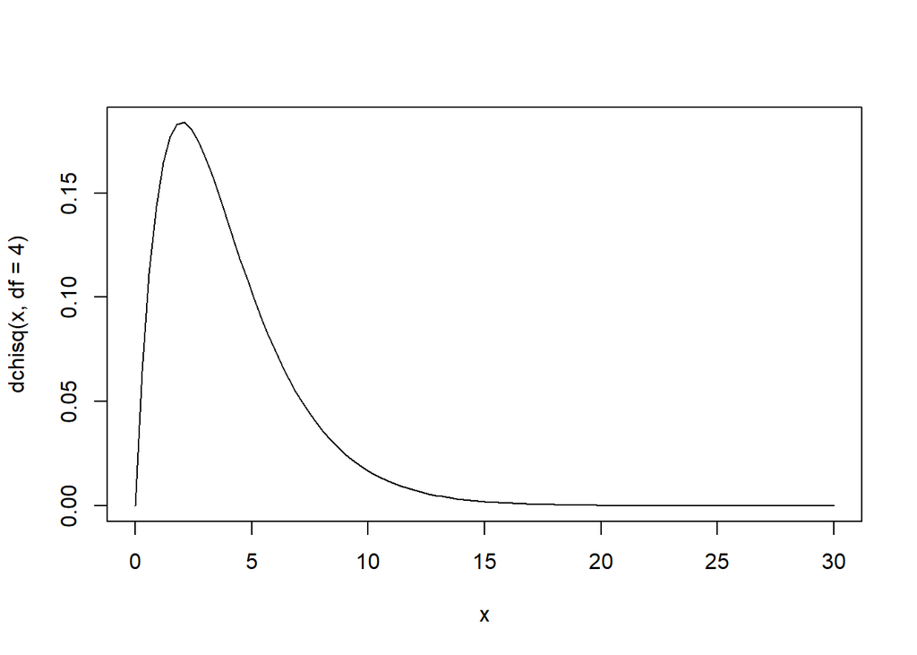

```r
curve(dchisq(x, df=4), from=0, to=30)
```

# 2 Question 2

Nothing to see here

# 3 Question 3

## 3.1 Before After Workshop

Let $\mu_1$ be the mean value for before the workshop and let $\mu_2$ be the mean value for after the workshop

Alternatives: $H_0 : \mu_1 \geq \mu_2$ $H_1 : \mu_1 < \mu_2$

$\alpha = 0.05$

This is paired data so paired test to be done

```r
before <- c(12, 15, 10, 18, 14, 11, 16, 13, 17, 12)
after <- c(15, 18, 13, 20, 16, 14, 18, 15, 19, 14)

diff <- before - after
```

Need to check normality of diff

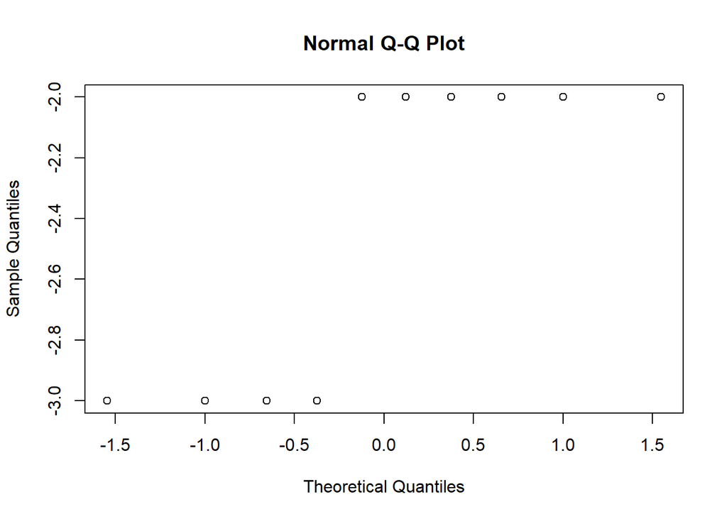

```r
qqnorm(diff)
```

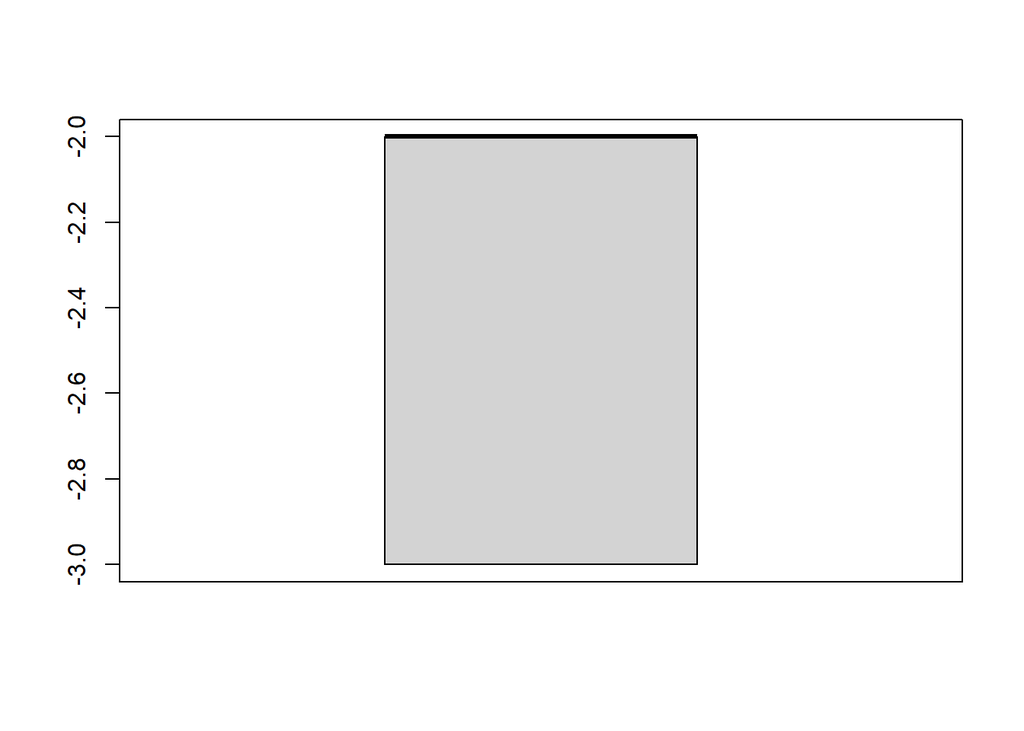

```r
boxplot(diff)
```

The differences are not normal so t-test is not valid. Will use Wilcoxon signed-rank test

So need to change Hypotheses, where M is the median

$H_0 : M_1 \geq M_2$

$H_1 : M_1 < M_2$

```r
wilcox.test(before, after, paired=TRUE, alternative = 'less')
```

```
##
##  Wilcoxon signed rank test with continuity correction
##
## data:  before and after
## V = 0, p-value = 0.002283
## alternative hypothesis: true location shift is less than 0
```

The p-value is < 0.05 so reject $H_0$

The median study hours before the workshop is less than the median study hours after the workshop

## 3.2 Mobile-phone

This is also not normal so Wilcoxon test again but not paired data this time

```r
x <- c(12.8, 3.5, 2.9, 9.4, 8.7, .7, .2, 2.8, 1.9, 2.8, 3.1, 15.8)
stem(x)
```

```
##
##   The decimal point is 1 digit(s) to the right of the |
##
##   0 | 01233334
##   0 | 99
##   1 | 3
##   1 | 6
```

```r
wilcox.test(x, mu=5, alt="greater")
```

```
##
##  Wilcoxon signed rank test with continuity correction
##
## data:  x
## V = 39, p-value = 0.5156
## alternative hypothesis: true location is greater than 5
```

## 3.3 Compare Schools

$H_0 : \mu_A = \mu_B$ $H_1 : \mu_A \neq \mu_B$

$\alpha = 0.05$

```r
school_A <- c(78, 85, 90, 76, 82, 79, 88, 91, 85, 80, 83, 87, 92, 84, 81)
school_B <- c(82, 88, 84, 79, 85, 83, 87, 90, 86, 81, 85, 89, 91, 87, 83)
```

Testing for normality

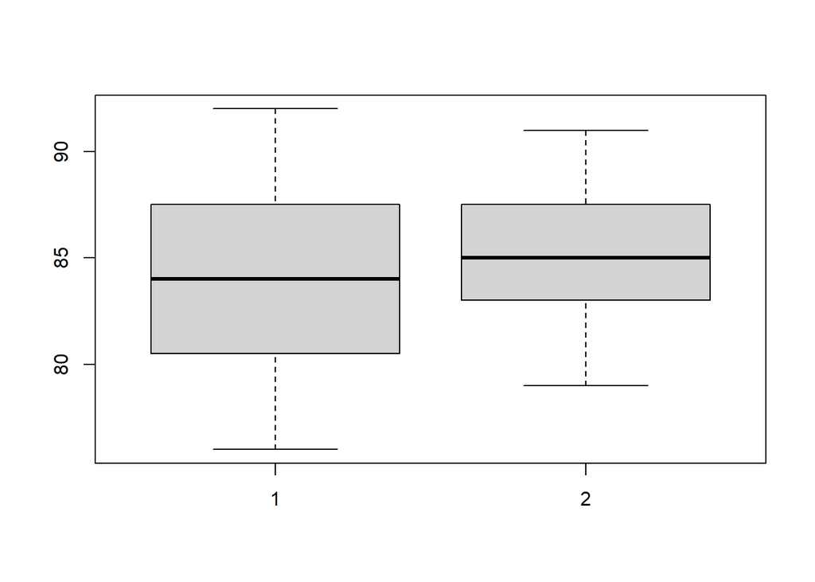

```r
boxplot(school_A, school_B)
```

That’s a normal boxplot for both of them, maybe the variances are different. Let’s use shapiro-wilk anyway

```r
shapiro.test(school_A)
```

```
##
##  Shapiro-Wilk normality test
##
## data:  school_A
## W = 0.97334, p-value = 0.9041
```

```r
shapiro.test(school_B)
```

```
##
##  Shapiro-Wilk normality test
##
## data:  school_B
## W = 0.98593, p-value = 0.9949
```

Both of those are very large values, so therefore assume normality. Finally we can use a t.test!

What about equal variance?

```r
bartlett.test(list(school_A,school_B))
```

```
##
##  Bartlett test of homogeneity of variances
##
## data:  list(school_A, school_B)
## Bartlett's K-squared = 1.6511, df = 1, p-value = 0.1988
```

Above 0.05 p-value so assume equal variance

Now the actual test

```r
t.test(school_A, school_B, equal.var=TRUE)
```

```
##
##  Welch Two Sample t-test
##
## data:  school_A and school_B
## t = -0.82564, df = 25.113, p-value = 0.4168
## alternative hypothesis: true difference in means is not equal to 0
## 95 percent confidence interval:
##  -4.425613  1.892280
## sample estimates:
## mean of x mean of y
##  84.06667  85.33333
```

p-value is > 0.05 therefore not enough evidence to reject the null hypothesis

Accept the two schools are simliar scores.

## 3.4 Drug vs Placebo

```r
drug_group <- c(8.1, 7.6, 8.9, 9.2, 7.8, 8.3, 9.1, 8.7, 9.0, 8.5, 8.6, 9.3)
placebo_group <- c(4.5, 10.2, 3.8, 12.1, 4.0, 11.3, 3.9, 10.8, 5.2, 9.7)
```

$H_0 : \mu_1 \leq \mu_2$

$H_1 : \mu_1 > \mu_2$

Test for normality

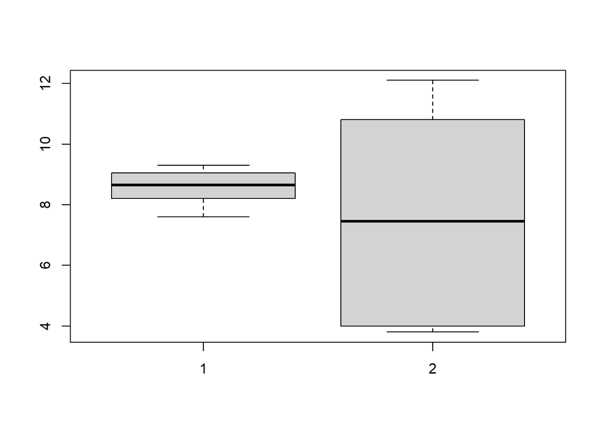

```r
boxplot(drug_group, placebo_group)
```

```r
shapiro.test(drug_group)
```

```
##
##  Shapiro-Wilk normality test
##
## data:  drug_group
## W = 0.94814, p-value = 0.61
```

```r
shapiro.test(placebo_group)
```

```
##
##  Shapiro-Wilk normality test
##
## data:  placebo_group
## W = 0.81316, p-value = 0.02094
```

Both boxplots look normalish, shapiro-wilk says drug group is normal but it does not agree with placebo group. However, they are both measuring the same data so I’m happy enough with saying both the populations are probably normal (I mentioned this idea in the lecture)

Equal variance, I doubt from the boxplot but let’s check.

```r
bartlett.test(list(drug_group, placebo_group))
```

```
##
##  Bartlett test of homogeneity of variances
##
## data:  list(drug_group, placebo_group)
## Bartlett's K-squared = 24.188, df = 1, p-value = 8.735e-07
```

that’s a very very small p-value so they don’t have equal variance! Should do a levene test too, leave that as an exercise

The hypothesis test

```r
t.test(drug_group, placebo_group, alt='greater')
```

```
##
##  Welch Two Sample t-test
##
## data:  drug_group and placebo_group
## t = 0.92527, df = 9.3683, p-value = 0.189
## alternative hypothesis: true difference in means is greater than 0
## 95 percent confidence interval:
##  -1.012856       Inf
## sample estimates:
## mean of x mean of y
##  8.591667  7.550000
```

not enough evidence etc etc

## 3.5 Penalties in World Cups

17/35 is the proportion of ones won by the team that went first

```r
prop.test(17, 35, p=0.5)
```

```
##
##  1-sample proportions test with continuity correction
##
## data:  17 out of 35, null probability 0.5
## X-squared = 0, df = 1, p-value = 1
## alternative hypothesis: true p is not equal to 0.5
## 95 percent confidence interval:
##  0.3172432 0.6572426
## sample estimates:
##         p
## 0.4857143
```

Not enough evidence to suggest etc etc

## 3.6 Proportion Test 2

```r
prop.test(c(45, 56), c(45+35, 56+47))
```

```
##
##  2-sample test for equality of proportions with continuity correction
##
## data:  c(45, 56) out of c(45 + 35, 56 + 47)
## X-squared = 0.010813, df = 1, p-value = 0.9172
## alternative hypothesis: two.sided
## 95 percent confidence interval:
##  -0.1374478  0.1750692
## sample estimates:
##    prop 1    prop 2
## 0.5625000 0.5436893
```

fail to reject, like all the others!

# 4 Question 4

## 4.1 Dice rolls

$H_0$: It follows the distribution

$H_1$: It does not follow

```r
observed_dice <- c(22, 21, 22, 27, 22, 36)

probs <- c(1/6,1/6,1/6,1/6,1/6,1/6)

result<-chisq.test(observed_dice, p=probs)
```

```r
result$p.value
```

```
## [1] 0.2423109
```

```r
result$expected
```

```
## [1] 25 25 25 25 25 25
```

Fail to reject again!

## 4.2 Letter Distribution

I’m getting lazy now in writing $H_0$ and $\alpha$, you should not forget them.

```r
expected_props <- c(29, 21, 17, 17, 16)/100
observed_letters <- c(100, 110, 80, 55, 14)

result<- chisq.test(observed_letters, p = expected_props)
```

```r
result$p.value
```

```
## [1] 2.684534e-11
```

```r
result$expected
```

```
## [1] 104.11  75.39  61.03  61.03  57.44
```

Very low p-value, reject null hypothesis (finally!) so this text was probably not from the English language.

## 4.3 Star Trek

```r
star_trek <- matrix(c(135, 10, 19, 10, 215, 46), nrow=3, byrow=TRUE)
rownames(star_trek) <- c("Blue", "Gold", "Red")
colnames(star_trek) <- c("Alive", "Dead")
```

```r
star_trek
```

```
##      Alive Dead
## Blue   135   10
## Gold    19   10
## Red    215   46
```

```r
result <- chisq.test(star_trek)
result$expected
```

```
##      Alive Dead
## Blue 123.0 22.0
## Gold  24.6  4.4
## Red  221.4 39.6
```

```r
result$p.value
```

```
## [1] 0.0001718649
```

p-value is < 0.05 so reject null-hypothesis etc.

```r
5/6
```

```
## [1] 0.8333333
```

that is greater than 80% of the entries so the test is valid despite R’s warning

## 4.4 Belts

```r
yesbelt <- c(12813, 647, 359, 42)
nobelt <- c(65963, 4000, 2642, 3037)
```

```r
result <- chisq.test(data.frame(yesbelt,nobelt))

result$expected
```

```
##         yesbelt    nobelt
## [1,] 12199.7490 66576.251
## [2,]   719.6638  3927.336
## [3,]   464.7538  2536.246
## [4,]   476.8334  2602.167
```

```r
result$p.value
```

```
## [1] 2.494424e-117
```

very low p-value so reject null hypothesis.

This means that level of injury and wearing a seat belt are dependent on one another. (It doesn’t say which way the dependence is, maybe wearing a seat-belt makes things worse! You need to do further investigation to see where the dependency is)

# 5 Question 5

## 5.1 Car Data

```r
column_names <- c("mpg","cylinder","displacement","horsepower","weight","acceleration","model_year","origin","car_name")

auto_data <- read.table("auto-mpg.data", header=FALSE, col.names = column_names, na.strings='?', stringsAsFactors=FALSE)
auto_data$origin <- factor(auto_data$origin, levels = c(1, 2, 3), labels = c("USA", "Europe", "Japan"))

auto_data
```

| mpg | cylinder | displacement | horsepower | weight | acceleration | model_year | origin | car_name |
| --- | --- | --- | --- | --- | --- | --- | --- | --- |
| 18.0 | 8 | 307.0 | 130 | 3504 | 12.0 | 70 | USA | chevrolet chevelle malibu |
| 15.0 | 8 | 350.0 | 165 | 3693 | 11.5 | 70 | USA | buick skylark 320 |
| 18.0 | 8 | 318.0 | 150 | 3436 | 11.0 | 70 | USA | plymouth satellite |
| 16.0 | 8 | 304.0 | 150 | 3433 | 12.0 | 70 | USA | amc rebel sst |
| 17.0 | 8 | 302.0 | 140 | 3449 | 10.5 | 70 | USA | ford torino |
| 15.0 | 8 | 429.0 | 198 | 4341 | 10.0 | 70 | USA | ford galaxie 500 |
| 14.0 | 8 | 454.0 | 220 | 4354 | 9.0 | 70 | USA | chevrolet impala |
| 14.0 | 8 | 440.0 | 215 | 4312 | 8.5 | 70 | USA | plymouth fury iii |
| 14.0 | 8 | 455.0 | 225 | 4425 | 10.0 | 70 | USA | pontiac catalina |
| 15.0 | 8 | 390.0 | 190 | 3850 | 8.5 | 70 | USA | amc ambassador dpl |

[output cut: 388 more lines]

```r
usa_mpg <- auto_data$mpg[auto_data$origin == "USA"]
europe_mpg <- auto_data$mpg[auto_data$origin == "Europe"]
```

These are large enough datasets that normality check is not needed. Can do equal variance too, I’d be shocked if they’re different

So test

$H_0: \mu_1 = \mu_2$

$H_1: \mu_1 \neq \mu_2$

```r
t.test(usa_mpg, europe_mpg, equal.var=TRUE)
```

```
##
##  Welch Two Sample t-test
##
## data:  usa_mpg and europe_mpg
## t = -8.6726, df = 106.73, p-value = 5.139e-14
## alternative hypothesis: true difference in means is not equal to 0
## 95 percent confidence interval:
##  -9.592665 -6.023124
## sample estimates:
## mean of x mean of y
##  20.08353  27.89143
```

Very low p-value (reject $H_0$)

There is a difference between mpg for usa and european cars

You can do some more here.

## 5.2 Differences in Marks

```r
sampledataset <- read.csv("SampleDataSet2014.csv")
head(sampledataset)
```

|  | ids | bday | enrolldate | expgradate | Rank | Major | Gender | Athlete | Height | Weight | Smoking | Sprint | MileMinDur | English | Reading | Math | Writing | State | LiveOnCampus | HowCommute | CommuteTime | SleepTime | StudyTime |
| --- | --- | --- | --- | --- | --- | --- | --- | --- | --- | --- | --- | --- | --- | --- | --- | --- | --- | --- | --- | --- | --- | --- | --- |
| 1 | 43783 | 3/22/1995 |  |  | NA |  | 0 | 0 | 72.35 | NA | 0 | 7.978 |  | 88.24 | 81.50 | 60.02 | 81.44 | In state | 1 | NA | NA | 7 | 1 |
| 2 | 20278 | 1/1/1995 |  |  | NA | Philosophy | 0 | 0 | 70.66 | 179.20 | 0 | 8.004 | 0:06:21 | 89.45 | 85.25 | 70.19 | 73.27 |  | 1 | NA | NA | 5 | 2 |
| 3 | 20389 | 12/31/1994 |  |  | NA |  | 0 | 0 | 70.68 | 198.52 | 0 | NA | 0:07:00 | 96.73 | 86.88 | 71.20 | 84.24 | In state | NA | NA | NA | 8 | 7 |
| 4 | 22820 | 12/1/1994 |  |  | NA | business administration | 1 | 0 | NA | 198.34 | NA | 8.473 | 0:12:44 | 74.06 | 88.68 | 55.89 | 73.16 | In state | 1 | NA | NA | 2 | 6 |
| 5 | 24559 | 11/10/1994 |  |  | NA |  | 1 | 1 | 67.43 | 128.17 | 2 | NA | 0:06:25 | 82.61 | 77.30 | 65.52 | 80.45 | Out of state | 1 | NA | NA | 7 | 3 |
| 6 | 28980 | 9/17/1994 |  |  | NA | astrophysics | 0 | 1 | 68.45 | 171.61 | 0 | 4.650 | 0:07:24 | 70.10 | NA | 61.40 | 77.48 | In state | 1 | NA | NA | 8 | 3 |

Extract English Scores and Math scores, but only if they both exist. Probably a more efficient way of doing this that will work for later ones more easily too

```r
## Filter
filterdataset <- sampledataset[!is.na(sampledataset$Math) & !is.na(sampledataset$English), ]
head(filterdataset)
```

|  | ids | bday | enrolldate | expgradate | Rank | Major | Gender | Athlete | Height | Weight | Smoking | Sprint | MileMinDur | English | Reading | Math | Writing | State | LiveOnCampus | HowCommute | CommuteTime | SleepTime | StudyTime |
| --- | --- | --- | --- | --- | --- | --- | --- | --- | --- | --- | --- | --- | --- | --- | --- | --- | --- | --- | --- | --- | --- | --- | --- |
| 1 | 43783 | 3/22/1995 |  |  | NA |  | 0 | 0 | 72.35 | NA | 0 | 7.978 |  | 88.24 | 81.50 | 60.02 | 81.44 | In state | 1 | NA | NA | 7 | 1 |
| 2 | 20278 | 1/1/1995 |  |  | NA | Philosophy | 0 | 0 | 70.66 | 179.20 | 0 | 8.004 | 0:06:21 | 89.45 | 85.25 | 70.19 | 73.27 |  | 1 | NA | NA | 5 | 2 |
| 3 | 20389 | 12/31/1994 |  |  | NA |  | 0 | 0 | 70.68 | 198.52 | 0 | NA | 0:07:00 | 96.73 | 86.88 | 71.20 | 84.24 | In state | NA | NA | NA | 8 | 7 |
| 4 | 22820 | 12/1/1994 |  |  | NA | business administration | 1 | 0 | NA | 198.34 | NA | 8.473 | 0:12:44 | 74.06 | 88.68 | 55.89 | 73.16 | In state | 1 | NA | NA | 2 | 6 |
| 5 | 24559 | 11/10/1994 |  |  | NA |  | 1 | 1 | 67.43 | 128.17 | 2 | NA | 0:06:25 | 82.61 | 77.30 | 65.52 | 80.45 | Out of state | 1 | NA | NA | 7 | 3 |
| 6 | 28980 | 9/17/1994 |  |  | NA | astrophysics | 0 | 1 | 68.45 | 171.61 | 0 | 4.650 | 0:07:24 | 70.10 | NA | 61.40 | 77.48 | In state | 1 | NA | NA | 8 | 3 |

```r
math_scores <- filterdataset$Math
english_scores <- filterdataset$English
```

These are paired data. Dataset is large enough so no need for CLT

```r
t.test(math_scores, english_scores, paired=TRUE)
```

```
##
##  Paired t-test
##
## data:  math_scores and english_scores
## t = -36.313, df = 397, p-value < 2.2e-16
## alternative hypothesis: true mean difference is not equal to 0
## 95 percent confidence interval:
##  -18.23373 -16.36079
## sample estimates:
## mean difference
##       -17.29726
```

So there is a difference in scores. We could investigate a little closer with a one-tailed test

```r
t.test(math_scores, english_scores, paired=TRUE, alt="less")
```

```
##
##  Paired t-test
##
## data:  math_scores and english_scores
## t = -36.313, df = 397, p-value < 2.2e-16
## alternative hypothesis: true mean difference is less than 0
## 95 percent confidence interval:
##       -Inf -16.51191
## sample estimates:
## mean difference
##       -17.29726
```

We’ve enough evidence to suggest that Maths scores are lower than English scores on these tests (which a mean of -17.29726 would’ve been obvious, but now we know how to do it rigorously)

## 5.3 Smokers

```r
data <- read.csv("SampleDataSet2014.csv")
head(data)
```

|  | ids | bday | enrolldate | expgradate | Rank | Major | Gender | Athlete | Height | Weight | Smoking | Sprint | MileMinDur | English | Reading | Math | Writing | State | LiveOnCampus | HowCommute | CommuteTime | SleepTime | StudyTime |
| --- | --- | --- | --- | --- | --- | --- | --- | --- | --- | --- | --- | --- | --- | --- | --- | --- | --- | --- | --- | --- | --- | --- | --- |
| 1 | 43783 | 3/22/1995 |  |  | NA |  | 0 | 0 | 72.35 | NA | 0 | 7.978 |  | 88.24 | 81.50 | 60.02 | 81.44 | In state | 1 | NA | NA | 7 | 1 |
| 2 | 20278 | 1/1/1995 |  |  | NA | Philosophy | 0 | 0 | 70.66 | 179.20 | 0 | 8.004 | 0:06:21 | 89.45 | 85.25 | 70.19 | 73.27 |  | 1 | NA | NA | 5 | 2 |
| 3 | 20389 | 12/31/1994 |  |  | NA |  | 0 | 0 | 70.68 | 198.52 | 0 | NA | 0:07:00 | 96.73 | 86.88 | 71.20 | 84.24 | In state | NA | NA | NA | 8 | 7 |
| 4 | 22820 | 12/1/1994 |  |  | NA | business administration | 1 | 0 | NA | 198.34 | NA | 8.473 | 0:12:44 | 74.06 | 88.68 | 55.89 | 73.16 | In state | 1 | NA | NA | 2 | 6 |
| 5 | 24559 | 11/10/1994 |  |  | NA |  | 1 | 1 | 67.43 | 128.17 | 2 | NA | 0:06:25 | 82.61 | 77.30 | 65.52 | 80.45 | Out of state | 1 | NA | NA | 7 | 3 |
| 6 | 28980 | 9/17/1994 |  |  | NA | astrophysics | 0 | 1 | 68.45 | 171.61 | 0 | 4.650 | 0:07:24 | 70.10 | NA | 61.40 | 77.48 | In state | 1 | NA | NA | 8 | 3 |

```r
clean_data <- data[!is.na(data$Smoking) & !is.na(data$Gender), ]
```

```r
smoking_gender <- table(clean_data$Gender, clean_data$Smoking)
head(smoking_gender)
```

```
##
##       0   1   2
##   0 149  13  31
##   1 148  24  37
```

```r
clean_data$Smoking <- factor(as.numeric(as.character(clean_data$Smoking)), levels = c(0, 1, 2), labels = c("Nonsmoker", "Past Smoker", "Current Smoker"))
head(clean_data)
```

|  | ids | bday | enrolldate | expgradate | Rank | Major | Gender | Athlete | Height | Weight | Smoking | Sprint | MileMinDur | English | Reading | Math | Writing | State | LiveOnCampus | HowCommute | CommuteTime | SleepTime | StudyTime |
| --- | --- | --- | --- | --- | --- | --- | --- | --- | --- | --- | --- | --- | --- | --- | --- | --- | --- | --- | --- | --- | --- | --- | --- |
| 1 | 43783 | 3/22/1995 |  |  | NA |  | 0 | 0 | 72.35 | NA | Nonsmoker | 7.978 |  | 88.24 | 81.50 | 60.02 | 81.44 | In state | 1 | NA | NA | 7 | 1 |
| 2 | 20278 | 1/1/1995 |  |  | NA | Philosophy | 0 | 0 | 70.66 | 179.20 | Nonsmoker | 8.004 | 0:06:21 | 89.45 | 85.25 | 70.19 | 73.27 |  | 1 | NA | NA | 5 | 2 |
| 3 | 20389 | 12/31/1994 |  |  | NA |  | 0 | 0 | 70.68 | 198.52 | Nonsmoker | NA | 0:07:00 | 96.73 | 86.88 | 71.20 | 84.24 | In state | NA | NA | NA | 8 | 7 |
| 5 | 24559 | 11/10/1994 |  |  | NA |  | 1 | 1 | 67.43 | 128.17 | Current Smoker | NA | 0:06:25 | 82.61 | 77.30 | 65.52 | 80.45 | Out of state | 1 | NA | NA | 7 | 3 |
| 6 | 28980 | 9/17/1994 |  |  | NA | astrophysics | 0 | 1 | 68.45 | 171.61 | Nonsmoker | 4.650 | 0:07:24 | 70.10 | NA | 61.40 | 77.48 | In state | 1 | NA | NA | 8 | 3 |
| 7 | 33312 | 7/27/1994 |  |  | NA | Anthropology | 0 | 1 | 68.56 | 163.96 | Nonsmoker | 4.750 | 0:05:47 | 78.98 | 87.53 | 76.71 | 70.79 | In state | 1 | NA | NA | 9 | 9 |

```r
smoking_gender <- table(clean_data$Gender, clean_data$Smoking)
head(smoking_gender)
```

```
##
##     Nonsmoker Past Smoker Current Smoker
##   0       149          13             31
##   1       148          24             37
```

```r
chi_result <- chisq.test(smoking_gender)
chi_result
```

```
##
##  Pearson's Chi-squared test
##
## data:  smoking_gender
## X-squared = 3.1713, df = 2, p-value = 0.2048
```

p-value is > 0.05, not enough evidence to reject null hypothesis. That means Gender and Smoking are independent variables